# Final Project

Brian Tran/195006098

Due: Wednesday, 12/14 at noon (Canvas submission)

```r
#Load packages
library(ggplot2)
library(rstanarm)
library(bayesplot)
library(bayesrules)
library(tidyverse)
library(tidybayes)
library(broom.mixed)
```

```r
#Read in dataset
library(readr)
health_insurance <- read.csv("health_insurance.csv", stringsAsFactors = TRUE)
```

The data is originally from Chapter 6 of the textbook Machine Learning with R by Brett Lantz but was found and downloaded through a kaggle dataset uploaded by Miri Choi at https://www.kaggle.com/datasets/mirichoi0218/insurance. The data was generated for the book using information from the U.S. Census Bureau. Thus it still captures important correlations in real data. There are 1338 subjects possessing variables that reflect health like BMI and smoking status, demographic information like age, sex, and residential region of the US, and number of children covered by the insurance. These predictors can be used on the response variable, medical expenses billed. This data interests me as it seems relevant and useful for every US resident, especially those at higher risk such as elderly, overweight people, or smokers.

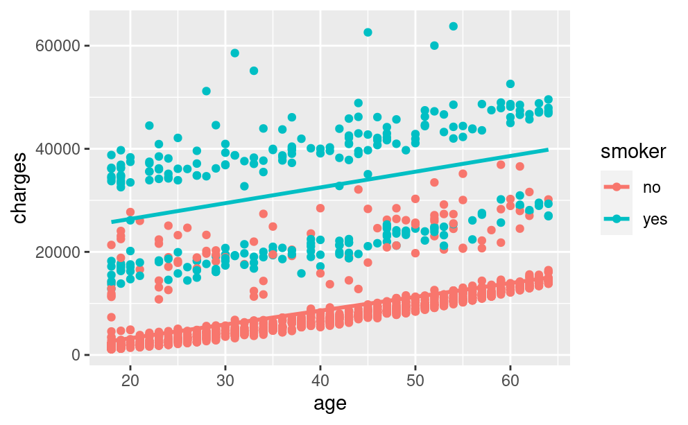

```r
#Plot of observed relationship between medical expense, age, and smoking:
ggplot(health_insurance, aes(x = age, y = charges, color = smoker)) +
  geom_point() +
  geom_smooth(method = "lm", se = FALSE)
```

We observe a generally positive correlation between age and medical expenses, as well as smokers having higher costs on average than non-smokers. This can be explained by smoking being a risk factor to preventable diseases such as lung cancer, heart disease, stroke, and more.

```r
#Default rstanarm priors with the assumption that average charges tend to be around 20000:
health_main <- stan_glm(
  charges ~ age + smoker,
  data = health_insurance, family = gaussian,
  prior_intercept = normal(20000, 2.5, autoscale = TRUE),
  prior = normal(0, 2.5, autoscale = TRUE),
  prior_aux = exponential(1, autoscale = TRUE),
  chains = 4, iter = 5000*2,, seed = 84735)
```

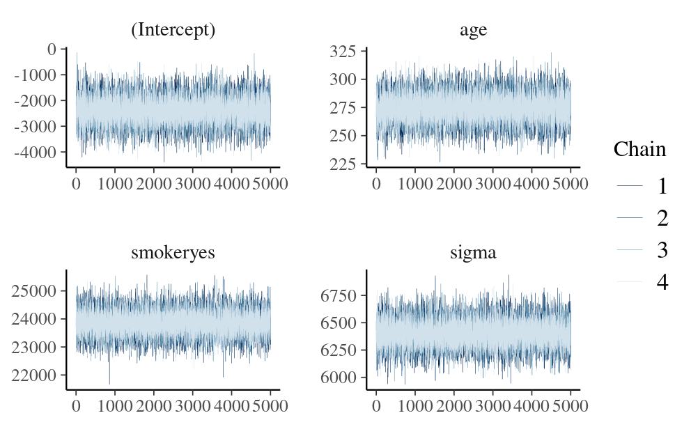

```r
#MCMC diagnostics
mcmc_trace(health_main, size = 0.1)
```

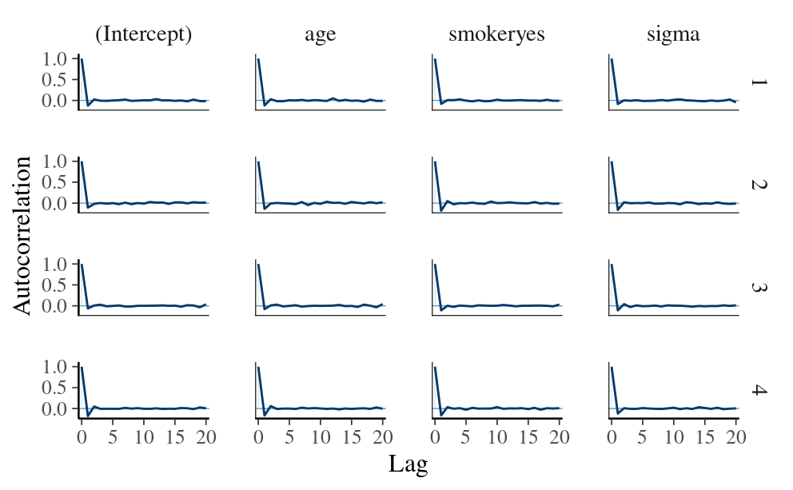

```r
mcmc_acf(health_main)
```

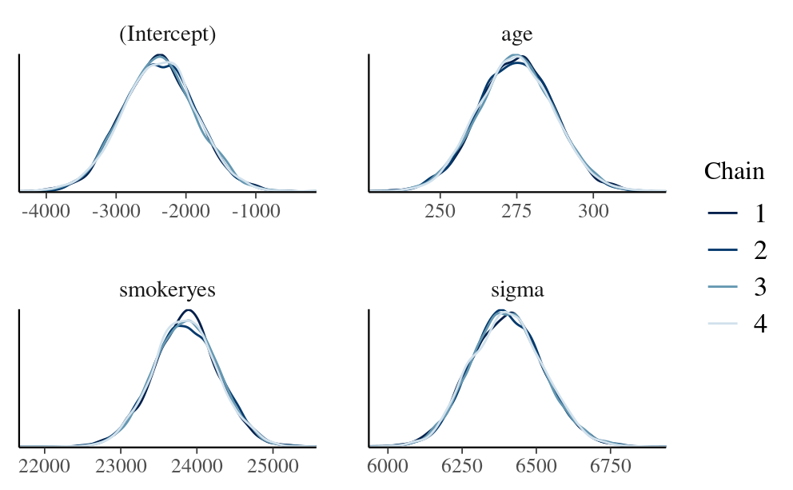

```r
mcmc_dens_overlay(health_main)
```

```r
neff_ratio(health_main)
```

```
(Intercept)         age   smokeryes       sigma
    1.24815     1.25620     1.32870     1.29230
```

```r
rhat(health_main)
```

```
(Intercept)         age   smokeryes       sigma
  1.0000254   1.0000389   0.9999359   0.9999484
```

The MCMC diagnostics all worked well. The trace plot and autocorrelation plot indicate the chain is stable and mixing quickly. The density plot shows a good approximation for the posterior. The effective sample size ratio is well above 0.1 (and even above 1 which is not typically true) and the r-hat is close to 1, providing evidence that the chain behaves like an independent sample.

```r
#Posterior summary statistics
tidy(health_main, effects = c("fixed", "aux"),
     conf.int = TRUE, conf.level = 0.80)
```

| term | estimate | std.error | conf.low | conf.high |
| --- | --- | --- | --- | --- |
| (Intercept) | -2388.1684 | 527.98715 | -3068.6438 | -1707.3867 |
| age | 274.8003 | 12.51925 | 258.9063 | 290.6906 |
| smokeryes | 23855.0763 | 426.38812 | 23304.0924 | 24405.5466 |
| sigma | 6400.0159 | 123.07232 | 6245.1278 | 6561.7321 |
| mean_PPD | 13271.1323 | 245.81030 | 12956.7349 | 13587.4670 |

The intercept is negative because it has no interpretation as the model does not take into account 0 year olds. For every one year increase in age, we expect medical charges to increase by roughly $274.80 for all patients. When a smoker and non-smoker are the same age, we expect smokers to have charges totaling $23,855.08 more than a patient that does not smoke.

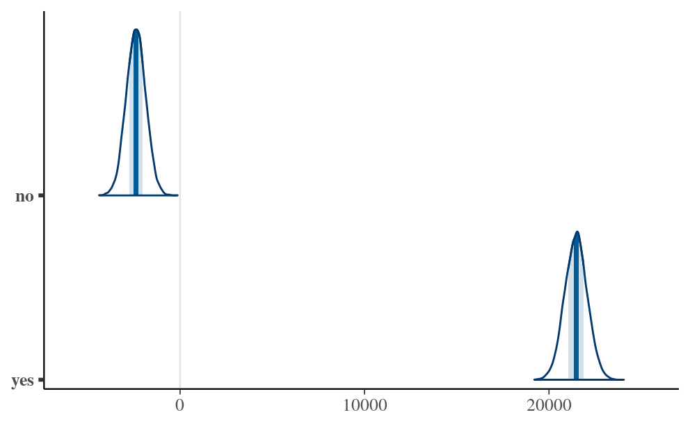

```r
#Posterior models of typical medical charges for smokers and non-smokers
as.data.frame(health_main) %>%
  mutate(no = `(Intercept)`,
         yes = `(Intercept)` + smokeryes) %>%
  mcmc_areas(pars = c("no", "yes"))
```

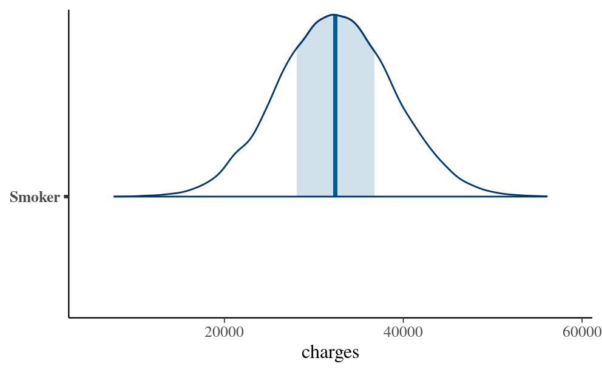

```r
#Prediction for 40 year old smoker with main model
set.seed(84735)
charges_prediction <- posterior_predict(
  health_main,
  newdata = data.frame(age = c(40),
                       smoker = c("yes")))
mcmc_areas(charges_prediction) +
  xlab("charges") +
  ggplot2::scale_y_discrete(labels = c("Smoker"))
```

We can anticipate medical charges to be roughly between $20000 and $45000 for 40 year old patients that smoke.

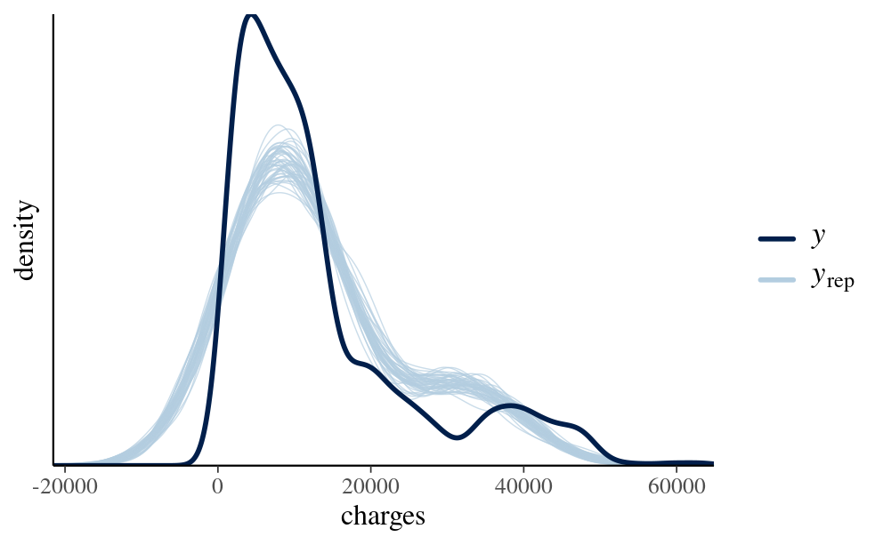

```r
#Visual posterior predictive check of main model
pp_check(health_main) +
  xlab("charges") +
  ylab("density")
```

The posterior simulations of Y exhibit higher central tendency and variability than the observed Y values. The model violates the assumptions that the relationship between Y and X is linear and normal variability for all values of X.

```r
#Take log transform of Y to improve model by addressing violation of assumptions (prior intercept was selected by looking at range of logcharges in health_insurance dataset)
health_insurance$logcharges=log(health_insurance$charges)
health_transform <- stan_glm(
  logcharges ~ age + smoker,
  data = health_insurance, family = gaussian,
  prior_intercept = normal(8.5, 0.75),
  prior = normal(0, 2.5, autoscale = TRUE),
  prior_aux = exponential(1, autoscale = TRUE),
  chains = 4, iter = 5000*2,, seed = 84735)
```

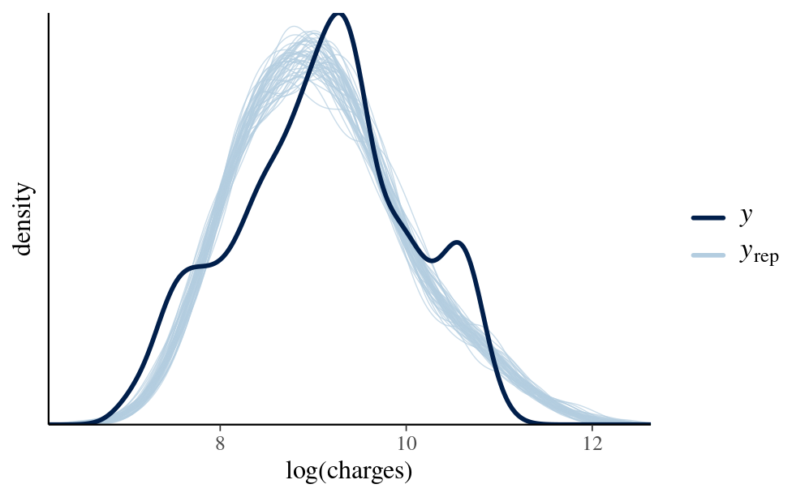

```r
#Visual posterior predictive check of transformed model
pp_check(health_transform) +
  xlab("log(charges)") +
  ylab("density")
```

This posterior predictive check suggests that the transformation helped in capturing medical charges but there could still be improvements to pick up the bimodality.

```r
#Transformed model with interaction between age and smoking status
health_interaction <- stan_glm(
  logcharges ~ smoker + age + smoker:age,
  data = health_insurance, family = gaussian,
  prior_intercept = normal(8.5, 0.75),
  prior = normal(0, 2.5, autoscale = TRUE),
  prior_aux = exponential(1, autoscale = TRUE),
  chains = 4, iter = 5000*2,, seed = 84735)
```

```r
tidy(health_interaction, effects = c("fixed", "aux"),
     conf.int = TRUE, conf.level = 0.80)
```

| term | estimate | std.error | conf.low | conf.high |
| --- | --- | --- | --- | --- |
| (Intercept) | 7.13363062 | 0.0396142103 | 7.08320028 | 7.18352203 |
| smokeryes | 2.77112419 | 0.0863043986 | 2.66110756 | 2.88321912 |
| age | 0.04201623 | 0.0009461917 | 0.04080705 | 0.04321570 |
| smokeryes:age | -0.03162813 | 0.0020839621 | -0.03435882 | -0.02898226 |
| sigma | 0.43475516 | 0.0084767819 | 0.42421514 | 0.44598159 |
| mean_PPD | 9.09856838 | 0.0168941249 | 9.07682571 | 9.12033244 |

The 80% posterior credible interval for the interaction coefficient is entirely below zero but not by much, ranging from -0.034 and -0.029, suggesting that the association between charges and age is slightly more negative in smokers than non-smokers.

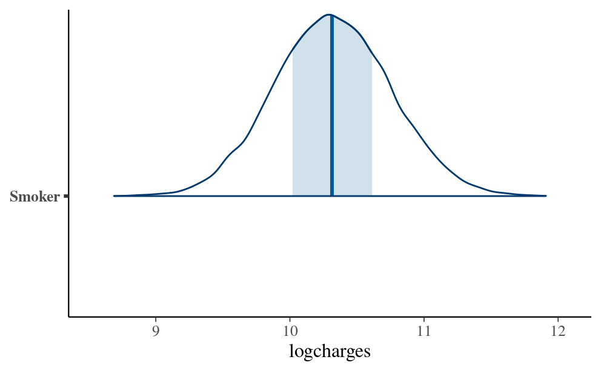

```r
#Prediction for 40 year old smoker with interaction model
set.seed(84735)
charges_prediction2 <- posterior_predict(
  health_interaction,
  newdata = data.frame(age = c(40),
                       smoker = c("yes")))
mcmc_areas(charges_prediction2) +
  xlab("logcharges") +
  ggplot2::scale_y_discrete(labels = c("Smoker"))
```

We can anticipate logcharges to be roughly between 9 and 11.5 for 40 year old patients that smoke.

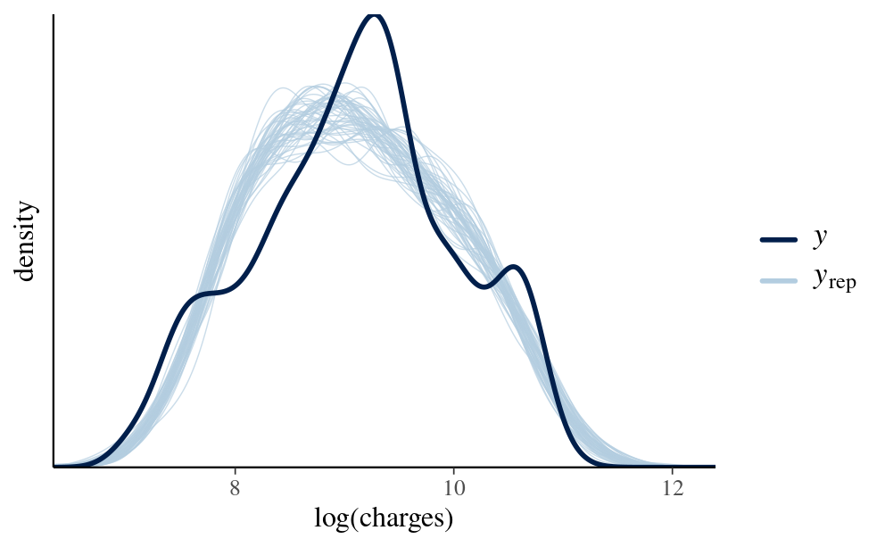

```r
#Visual posterior predictive check of transformed model with interaction term
pp_check(health_interaction) +
  xlab("log(charges)") +
  ylab("density")
```

This posterior predictive check suggests that the interaction term is not a clear improvement in capturing medical charges.

```r
#10-fold cross-validation to compare the posterior predictive quality of both transformed models
set.seed(84735)
prediction_summary_cv(model = health_transform, data = health_insurance, k = 10)
```

| fold | mae | mae_scaled | within_50 | within_95 |
| --- | --- | --- | --- | --- |
| 1 | 0.1250028 | 0.2631751 | 0.7238806 | 0.9328358 |
| 2 | 0.1406948 | 0.2998583 | 0.6791045 | 0.9104478 |
| 3 | 0.1137809 | 0.2395395 | 0.7388060 | 0.9552239 |
| 4 | 0.1549341 | 0.3300890 | 0.6315789 | 0.9097744 |
| 5 | 0.1386715 | 0.2937489 | 0.7014925 | 0.9477612 |
| 6 | 0.1596151 | 0.3414337 | 0.6567164 | 0.9104478 |
| 7 | 0.1452436 | 0.3102282 | 0.6842105 | 0.9323308 |
| 8 | 0.1407772 | 0.3020478 | 0.6417910 | 0.9253731 |
| 9 | 0.1219682 | 0.2584642 | 0.6940299 | 0.8955224 |
| 10 | 0.1730207 | 0.3638174 | 0.6641791 | 0.9701493 |

| mae | mae_scaled | within_50 | within_95 |
| --- | --- | --- | --- |
| 0.1413709 | 0.3002402 | 0.6815789 | 0.9289866 |

```r
prediction_summary_cv(model = health_interaction, data = health_insurance, k = 10)
```

| fold | mae | mae_scaled | within_50 | within_95 |
| --- | --- | --- | --- | --- |
| 1 | 0.2004587 | 0.4644856 | 0.6417910 | 0.9179104 |
| 2 | 0.1995868 | 0.4560841 | 0.7089552 | 0.9552239 |
| 3 | 0.1943950 | 0.4368013 | 0.6865672 | 0.9776119 |
| 4 | 0.2396592 | 0.5561518 | 0.5789474 | 0.9248120 |
| 5 | 0.1947362 | 0.4473085 | 0.6940299 | 0.9328358 |
| 6 | 0.1971137 | 0.4481768 | 0.6641791 | 0.9477612 |
| 7 | 0.2004322 | 0.4740917 | 0.6616541 | 0.9172932 |
| 8 | 0.1941505 | 0.4385929 | 0.7089552 | 0.9776119 |
| 9 | 0.1905264 | 0.4343026 | 0.7164179 | 0.9552239 |
| 10 | 0.2061069 | 0.4687131 | 0.7164179 | 0.9477612 |

| mae | mae_scaled | within_50 | within_95 |
| --- | --- | --- | --- |
| 0.2017166 | 0.4624708 | 0.6777915 | 0.9454046 |

```
NA
```

The model without an interaction term appears to provide the better posterior prediction of medical charges as it has smaller mae and mae_scaled and higher within_50 coverage statistics.

```r
#Evaluate and compare the expected log-predictive densities (ELPD) posterior predictive accuracy of both transformed models
set.seed(84735)
loo_1 <- loo(health_transform)
loo_2 <- loo(health_interaction)
c(loo_1$estimates[1], loo_2$estimates[1])
```

```
[1] -890.8037 -788.2937
```

```r
loo_compare(loo_1, loo_2)
```

```
                   elpd_diff se_diff
health_interaction    0.0       0.0
health_transform   -102.5      16.8
```

The ELPD for the transformed model without an interaction term is estimated to be 102.5 lower than that of the model with an interaction term and an estimated difference in ELPD with a standard error of 16.8. The ELPD for the interaction model is significantly higher since (-890.8037-(-788.2937))+2(16.8) = -68.91 < 0. In other words, ELPD of health_transform is at least two standard deviations below ELPD of health_interaction.

## Honor Pledge

On my honor, I have neither received nor given any unauthorized assistance on this project

- SIGNED: Brian Tran